# NC State Senate Facebook Posts (Part 1)

Ryan Wesslen

Jan 1, 2017

### Pre-processing & Exploration

#### Counts

Let’s read in two datasets: the senators and their public Facebook posts. The posts were collected through Facebook’s public API via R’s `Rfacebook` package. You can view the pseudo code used to pull this data from the file in the code folder of the GitHub directory.

```r
fbData <- read.csv("~/Dropbox (UNC Charlotte)/NCStateSenateFacebook/data/facebookPosts.csv", stringsAsFactors = F)
Senators <- read.csv("~/Dropbox (UNC Charlotte)/NCStateSenateFacebook/data/NCSenate.csv", stringsAsFactors = F)
```

Now let’s merge the two datasets and then filter to only Facebook posts from 2015 and 2016.

Note – this data was pulled on 12-23 and excludes any posts that have been posted since that date. Also, the number of responses (likes, comments, shares) were as of 12-23 and could have changed since that date.

```r
library(dplyr)
fbData <- merge(fbData, Senators, by.x = "from_id", by.y = "Facebook")
model <- subset(fbData, substr(created_time,1,4) %in% c("2015","2016"))
```

This leaves 7,813 facebook posts.

Let’s explore the number of posts and the average number of likes, comments, shares by party.

```r
model %>%
  group_by(Party) %>%
  summarise(AvgLikes = mean(likes_count), ComCount = mean(comments_count), ShCount = mean(shares_count), Count=n())
```

```
## # A tibble: 2 × 5
##        Party  AvgLikes ComCount  ShCount Count
##        <chr>     <dbl>    <dbl>    <dbl> <int>
## 1 Democratic 214.38212 17.12804 80.93271  3983
## 2 Republican  58.67755 10.86762 45.53760  3830
```

So we have about the same number of posts for each party – however, notice that, on average, Democrat state senators have a larger response by Facebook users (more likes, more comments, and more shares on average).

But there are different types of Facebook posts: links, photo, videos, event notifications and regular posts (status or note).

How does the number of posts differ by the type of post?

```r
table(model$Party, model$type)
```

```
##
##              event link note photo status video
##   Democratic    98 1884    1  1471    373   156
##   Republican    26 1425    5  1667    427   280
```

The count is fairly even across party but it’s clear there are two main types of posts: links (42%) and photos (40%). Statuses, videos and events make up the remaining (about 18%).

How have these trends changed over time?

#### Counts over time

First, let’s consider the total number of posts by plotting it by party.

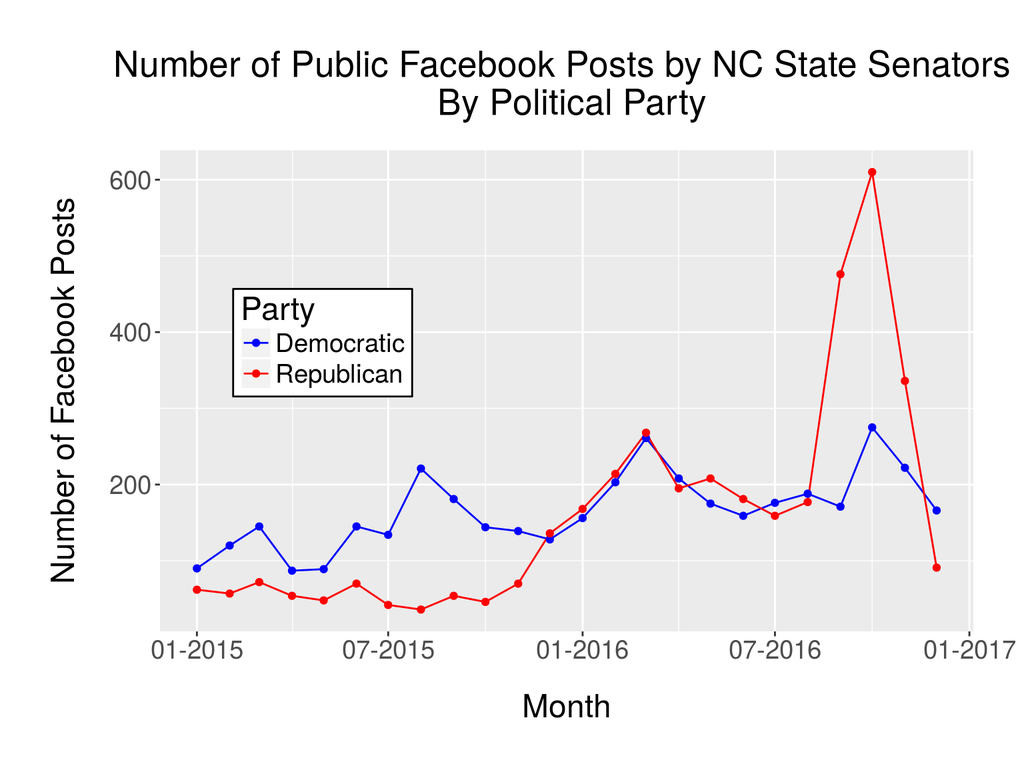

```r
library(ggplot2); library(scales)

plotData <- model %>%
  group_by(Date=substr(created_time,1,7), Party) %>%
  summarise(Posts=n(), Comments=sum(comments_count), Shares=sum(shares_count), Likes=sum(likes_count))

plotData$Month <- as.Date(paste0(plotData$Date,"-01"))

ggplot(data=plotData, aes(x=Month, y=Posts, group=Party, colour=Party)) +
  geom_line() +
  geom_point() +
  xlab("Month") + ylab("Number of Facebook Posts") + # Set axis labels
  ggtitle("Number of Public Facebook Posts by NC State Senators \n By Political Party")  +   # Set title
  scale_color_manual(breaks = c("Democratic","Republican"), values=c("blue","red")) + # Manually change to blue and red
  scale_x_date(labels = date_format("%m-%Y")) +
  theme(text = element_text(size=18)) +
  theme(legend.position = c(0.2,0.6), legend.background = element_rect(colour = "black")) +
  theme(plot.margin = unit(c(1,1,1,1), "cm")) +
  theme(axis.title.x=element_text(margin=margin(20,0,0,0))) +
  theme(axis.title.y=element_text(angle=90, margin=margin(0,20,0,0))) +
  theme(plot.title=element_text(size=20, margin=margin(0,0,20,0)))
```

How does this count over time change relative to the type of post (link, photo or all other types)?

[figure not shown]

```r
model$adjtype <- ifelse(model$type %in% c("link","photo"),model$type,"status or video")

plotData <- model %>%
  group_by(Date=substr(created_time,1,7), Party, adjtype) %>%
  summarise(Posts=n(), Comments=sum(comments_count), Shares=sum(shares_count), Likes=sum(likes_count))

plotData$Month <- as.Date(paste0(plotData$Date,"-01"))

ggplot(data=plotData, aes(x=Month, y=Posts, group=Party, colour=Party)) +
  geom_line() +
  geom_point() +
  xlab("Month") + ylab("Number of Facebook Posts") + # Set axis labels
  ggtitle("Number of Public Facebook Posts by NC State Senators \n By Political Party")  +   # Set title
  scale_color_manual(breaks = c("Democratic","Republican"), values=c("blue","red")) + # Manually change to blue and red
  facet_grid(adjtype ~ .) +
  scale_x_date(labels = date_format("%m-%Y")) +
  theme(text = element_text(size=18)) +
  theme(legend.position = "bottom", legend.background = element_rect(colour = "black")) +
  theme(plot.margin = unit(c(1,1,1,1), "cm")) +
  theme(axis.title.x=element_text(margin=margin(20,0,0,0))) +
  theme(axis.title.y=element_text(angle=90, margin=margin(0,20,0,0))) +
  theme(plot.title=element_text(size=20, margin=margin(0,0,20,0)))
```

It’s relatively similar to the totals. One difference is that a lot of the recent Republican growth was in photos (and somewhat statuses and videos).

For our purposes, I’m interested in posts that include text – so let’s count how many of the 7,813 posts do not include any text (e.g. only a photo or video).

```r
nrow(subset(model, is.na(message)))
```

```
## [1] 859
```

Let’s drop messages (for now) that do not include any text.

```r
model <- subset(model, !(is.na(message)))
```

Let’s summarise the count of posts and on average how long the posts are for each senator (by word count).

```r
library(quanteda)

agg <- model %>%
        group_by(Member, Party) %>%
        summarise(Count =n(), AvgWords = mean(ntoken(message)), AvgLikes = mean(likes_count), AvgComments = mean(comments_count), AvgShares = mean(shares_count)) %>%
        arrange(desc(Count))

head(agg, 10)
```

```
## Source: local data frame [10 x 7]
## Groups: Member [10]
##
##                      Member      Party Count  AvgWords   AvgLikes
##                       <chr>      <chr> <int>     <dbl>      <dbl>
## 1           Terry Van Duyn  Democratic  1049  55.22021 112.836988
## 2               Ralph Hise  Republican   835  70.79281   3.639521
## 3             Jeff Jackson  Democratic   561  51.76649 979.766488
## 4  Floyd B. McKissick, Jr.  Democratic   549 218.42623 229.451730
## 5             Tommy Tucker  Republican   526  99.01521   7.022814
## 6          Jay J. Chaudhuri Democratic   407  50.84275  40.366093
## 7              Phil Berger  Republican   306  62.42810 559.379085
## 8               Jeff Tarte  Republican   305  62.31475   3.744262
## 9             Mike Woodard  Democratic   270  84.28889   5.518519
## 10      Erica Smith-Ingram  Democratic   224  50.46429  15.477679
## # ... with 2 more variables: AvgComments <dbl>, AvgShares <dbl>
```

Let’s reorder the count three times: by the highest number of average likes, comments and shares.

```r
head(agg[order(agg$AvgLikes, decreasing = T),],10)
```

```
## Source: local data frame [10 x 7]
## Groups: Member [10]
##
##                      Member      Party Count  AvgWords  AvgLikes
##                       <chr>      <chr> <int>     <dbl>     <dbl>
## 1             Jeff Jackson  Democratic   561  51.76649 979.76649
## 2              Phil Berger  Republican   306  62.42810 559.37908
## 3  Floyd B. McKissick, Jr.  Democratic   549 218.42623 229.45173
## 4      E. S. (Buck) Newton  Republican   115  39.86957 115.90435
## 5           Terry Van Duyn  Democratic  1049  55.22021 112.83699
## 6           Michael V. Lee  Republican    39 118.30769  49.69231
## 7              Tom McInnis  Republican    71  67.49296  46.19718
## 8          David L. Curtis  Republican    73  78.58904  46.05479
## 9          Jay J. Chaudhuri Democratic   407  50.84275  40.36609
## 10      Valerie P. Foushee  Democratic    49  63.91837  39.65306
## # ... with 2 more variables: AvgComments <dbl>, AvgShares <dbl>
```

```r
head(agg[order(agg$AvgComments, decreasing = T),],10)
```

```
## Source: local data frame [10 x 7]
## Groups: Member [10]
##
##                      Member      Party Count  AvgWords  AvgLikes
##                       <chr>      <chr> <int>     <dbl>     <dbl>
## 1              Phil Berger  Republican   306  62.42810 559.37908
## 2             Jeff Jackson  Democratic   561  51.76649 979.76649
## 3  Floyd B. McKissick, Jr.  Democratic   549 218.42623 229.45173
## 4         Jerry W. Tillman  Republican     4  18.00000   9.00000
## 5      E. S. (Buck) Newton  Republican   115  39.86957 115.90435
## 6           Terry Van Duyn  Democratic  1049  55.22021 112.83699
## 7          David L. Curtis  Republican    73  78.58904  46.05479
## 8           Michael V. Lee  Republican    39 118.30769  49.69231
## 9              Tom McInnis  Republican    71  67.49296  46.19718
## 10     Norman W. Sanderson  Republican    56  45.96429  24.39286
## # ... with 2 more variables: AvgComments <dbl>, AvgShares <dbl>
```

```r
head(agg[order(agg$AvgShares, decreasing = T),],10)
```

```
## Source: local data frame [10 x 7]
## Groups: Member [10]
##
##                      Member      Party Count  AvgWords  AvgLikes
##                       <chr>      <chr> <int>     <dbl>     <dbl>
## 1              Phil Berger  Republican   306  62.42810 559.37908
## 2             Jeff Jackson  Democratic   561  51.76649 979.76649
## 3      E. S. (Buck) Newton  Republican   115  39.86957 115.90435
## 4  Floyd B. McKissick, Jr.  Democratic   549 218.42623 229.45173
## 5           Terry Van Duyn  Democratic  1049  55.22021 112.83699
## 6       Valerie P. Foushee  Democratic    49  63.91837  39.65306
## 7          David L. Curtis  Republican    73  78.58904  46.05479
## 8           Michael V. Lee  Republican    39 118.30769  49.69231
## 9          Ronald J. Rabin  Republican   179  87.26257  24.93296
## 10        Paul A. Lowe, Jr. Democratic    57  40.50877  27.08772
## # ... with 2 more variables: AvgComments <dbl>, AvgShares <dbl>
```

What’s clear is that from a social response, there are two major state senators: Jeff Jackson (D) and Phil Berger (R). This isn’t so surprising. Both have the highest number of Facebook likes on their pages (Berger has over 120k and Jackson has nearly 50k). This is also similar to the number of Twitter followers (see [my earlier post](https://wesslen.github.io/social%20media/nc-state-senator-twitter-network/) on the state senators’ Twitter follower network).

Another observation is that Jeff Jackson gets nearly double the number of likes (on average) than Phil Berger, yet has less than half the number of followers. Alternatively, Phil Berger gets a slightly higher number of comments and shares than Jeff Jackson on average. It’s interesting to compare likes and comments/shares as likes are a very simple response while comments and shares typically show a little more engagement as they elicit either a pseudo-endorsement (shares) or a verbal response (comment). My interpretation is that Senator Berger’s posts elicit a bit stronger sentiment (not clear positive or negative) while Senator Jackson’s posts elicit a larger “passive” response.

Through the public API, I was also able to pull all of the comments and like data (name/facebook ID) to identify who are the Facebook users who have commented or liked the posts of all the senators. If I get a chance, I’ll post a future post analyzing who are the users that are responding to the posts.

What is somewhat suprising is how little a response nearly all of the remaining state senators typically have. In fact, on average Senators Berger and Jackson get well more than the number of responses (likes, comments or shares) than all other NC state senators. The main message of this: Senators Berger and Jackson are the party leaders on Facebook for each’s respective party. This isn’t surprising given that Senator Berger is the Senate (and party) leader; however, it’s worth noting that Senator Jackson is a relatively new senator who only joined the Senate in May 2014 to fill an open seat.

### Automated Text Analysis

#### Data Preparation

Let’s now explore the content of the posts to determine what are the most salient topics discussed and analyze how the topics differ by political party.

To analyze, I’ll use the `quanteda` package.

```r
myCorpus <- corpus(model$message)
docvars(myCorpus, "Party") <- as.factor(model$Party)
docvars(myCorpus, "Time") <- as.integer(as.factor(substr(model$created_time,1,7)))
docvars(myCorpus, "ID") <- model$id
docvars(myCorpus, "Likes") <- model$likes_count
docvars(myCorpus, "Shares") <- model$shares_count
docvars(myCorpus, "Comments") <- model$comments_count
docvars(myCorpus, "Type") <- model$type

stpWords <- c("t.co", "https", "rt", "amp", "http", "t.c", "can", "u", "bit.ly","fb.me","facebook","posted", "also", "first", "second", "third", "one", "two", "three", "tt", "just", "said", "need", "going", "well", "like", "will", "www.gunnforncsenate.com","269eee9031f118516beeaa7c1","www.newsobserver.com","www.youtube.com", "NA")

dfm <- dfm(myCorpus,
           ignoredFeatures = c(stopwords("english"), stpWords),
           ngrams=c(1,2))
```

#### Word Clouds and Clustering

Let’s explore two word clouds – the first showing the raw frequencies (word size = frequency the word is mentioned) and by the [TF-IDF](https://en.wikipedia.org/wiki/Tf%E2%80%93idf) weighting (word size ~= importance of the word as measured by TF-IDF).

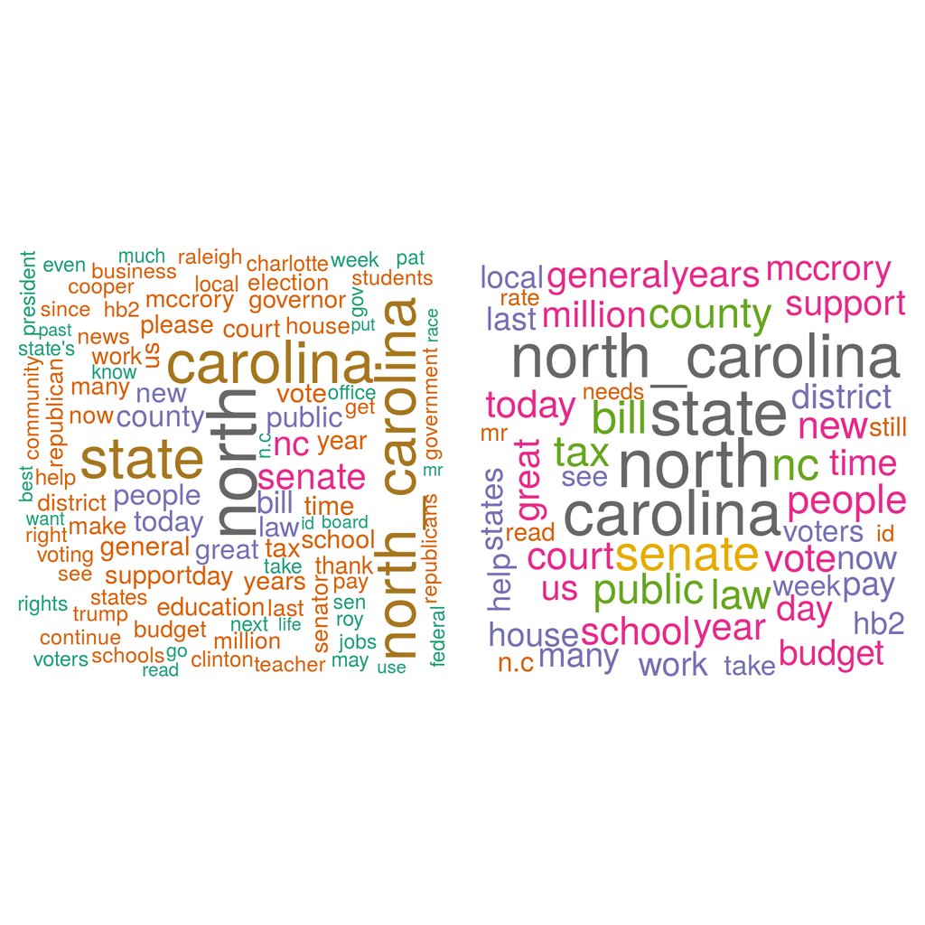

```r
vdfm <- trim(dfm, minCount = 10, minDoc = 5)

library(RColorBrewer)
par(mfrow = c(1,2),mar = c(0, 2, 0, 0 ))
plot(vdfm,  scale=c(3.5, .75), colors=brewer.pal(8, "Dark2"),
     random.order = F, rot.per=0.1, max.words=250, main = "Raw Counts")
plot(tfidf(vdfm),  scale=c(3.5, .75), colors=brewer.pal(8, "Dark2"),
     random.order = F, rot.per=0.1, max.words=250, main = "TF-IDF")
```

What’s clear is that there are a lot of North Carolina-related topics being discussed. But word clouds does not reveal the patterns of words being used together (i.e. topics).

As an exploratory exercise, we can use word clustering to identify words that tend to be used similarly (in the same post).

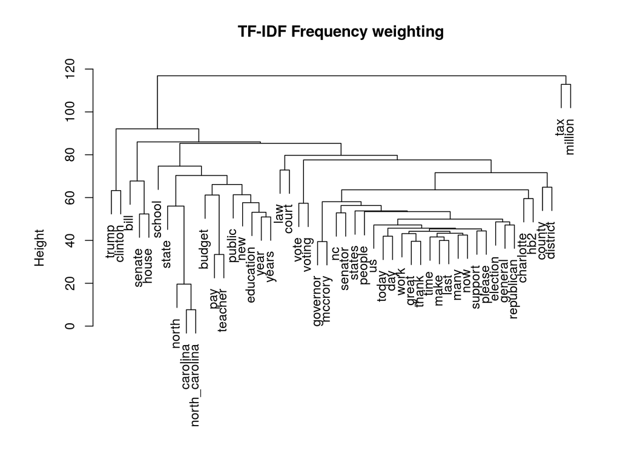

```r
par(mfrow = c(1,1),mar = c(2, 6, 4, 2))
twdfm <- trim(vdfm, minCount=50)  # Only keep words used at least 50 times
wordDfm <- sort(weight(twdfm, "tfidf"))
wordDfm <- t(wordDfm)[1:50,]  # keep the top 50 words
wordDistMat <- dist(wordDfm)
wordCluster <- hclust(wordDistMat)
plot(wordCluster, xlab="", main="TF-IDF Frequency weighting")
```

This is helpful and the cluster of words are generally intuitive (e.g. Trump/Clinton, Charlotte/HB2, Governor/McCrory). While this is a good “gut” check on the data, such analysis is insufficient at measuring and identifying the topics.

To analyze the topics, I’ll use [topic modeling](https://en.wikipedia.org/wiki/Topic_model), a framework of machine learning algorithms to analyze text through statistical patterns within large collection of documents (in our case, Facebook posts). Topic models are a class of unsupervised machine learning algorithms that, on their own, identify clusters of words that co-occur within the documents that we can interpret as the topics. Instead of knowing beforehand what are the topics discussed (e.g. dictionary-based/supervised methods), topic models allows the data to speak for itself by identifying the topics on its own.

I’ll use a cutting-edge extension of the topic models called Structural Topic Modeling (or STM) that will allow me to estimate, with statistical confidence, the effect political party has on the occurrence of each topic identified.

### Structural Topic Model

#### Data Preparation

Let’s first convert the data to a `stm`-based data structure.

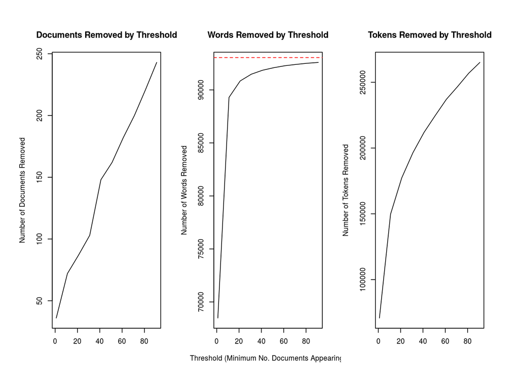

```r
library(stm)

# use quanteda converter to convert our Dfm
stmdfm <- convert(dfm, to = "stm", docvars = docvars(myCorpus))

plotRemoved(stmdfm$documents, lower.thresh = seq(1, 100, by = 10))
```

```r
out <- prepDocuments(stmdfm$documents, stmdfm$vocab, stmdfm$meta, lower.thresh = 3)
```

```
## Removing 82607 of 93050 terms (100446 of 331633 tokens) due to frequency
## Removing 48 Documents with No Words
## Your corpus now has 6902 documents, 10443 terms and 231187 tokens.
```

#### Determining Optimal Number of Topics

First, I’m going to run an analysis to give an estimate for the number of appropriate topics.

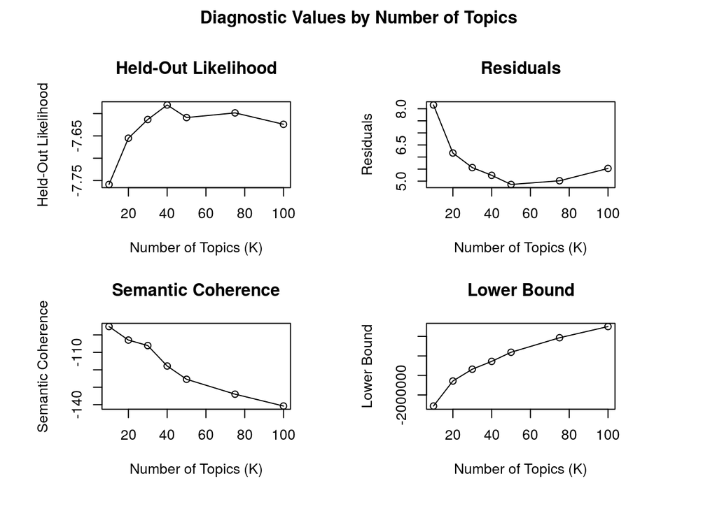

```r
K<-c(10,20,30,40,50,75,100)

kresult <- searchK(out$documents, out$vocab, K, prevalence=~Party + s(Time), data = out$meta, init.type = "Spectral")

plot(kresult)
```

From these results, I’m going to run a 40-topic model for simplicity.

```r
k <- 40

stmFit <- stm(out$documents, out$vocab, K = k, prevalence =~ Party + s(Time),
                 max.em.its = 200, data = out$meta, init.type = "Spectral", seed = 300)
```

Let’s save the results so we can come back to it in Part 2, where we’ll analyze the results.

```r
save(stmFit, file = "~/Dropbox (UNC Charlotte)/NCStateSenateFacebook/data/stmFit.RData")
save(out, file = "~/Dropbox (UNC Charlotte)/NCStateSenateFacebook/data/out.RData")
```